# Logistic regression

## Data description

The data approach student achievement in secondary education of two Portuguese schools. We are interested in two datasets presenting the performance in Mathematics (math) and Portuguese language (por).

The whole information about data is presented here (https://archive.ics.uci.edu/ml/datasets/Student+Performance).

Having combined two datasets we will analyze the following variables:

- school - student’s school (binary: ‘GP’ - Gabriel Pereira or ‘MS’ - Mousinho da Silveira)
- sex - student’s sex (binary: ‘F’ - female or ‘M’ - male)
- age - student’s age (numeric: from 15 to 22)
- address - student’s home address type (binary: ‘U’ - urban or ‘R’ - rural)
- famsize - family size (binary: ‘LE3’ - less or equal to 3 or ‘GT3’ - greater than 3)
- Pstatus - parent’s cohabitation status (binary: ‘T’ - living together or ‘A’ - apart)
- Medu - mother’s education (numeric: 0 - none, 1 - primary education (4th grade), 2 – 5th to 9th grade, 3 – secondary education or 4 – higher education)
- Fedu - father’s education (numeric: 0 - none, 1 - primary education (4th grade), 2 – 5th to 9th grade, 3 – secondary education or 4 – higher education)
- Mjob - mother’s job (nominal: ‘teacher’, ‘health’ care related, civil ‘services’ (e.g. administrative or police), ‘at_home’ or ‘other’)
- Fjob - father’s job (nominal: ‘teacher’, ‘health’ care related, civil ‘services’ (e.g. administrative or police), ‘at_home’ or ‘other’)
- reason - reason to choose this school (nominal: close to ‘home’, school ‘reputation’, ‘course’ preference or ‘other’)
- guardian - student’s guardian (nominal: ‘mother’, ‘father’ or ‘other’)
- traveltime - home to school travel time (numeric: 1 - <15 min., 2 - 15 to 30 min., 3 - 30 min. to 1 hour, or 4 - >1 hour)
- studytime - weekly study time (numeric: 1 - <2 hours, 2 - 2 to 5 hours, 3 - 5 to 10 hours, or 4 - >10 hours)
- schoolsup - extra educational support (binary: yes or no)
- famsup - family educational support (binary: yes or no)
- activities - extra-curricular activities (binary: yes or no)
- nursery - attended nursery school (binary: yes or no)
- higher - wants to take higher education (binary: yes or no)
- internet - Internet access at home (binary: yes or no)
- romantic - with a romantic relationship (binary: yes or no)
- famrel - quality of family relationships (numeric: from 1 - very bad to 5 - excellent)
- freetime - free time after school (numeric: from 1 - very low to 5 - very high)
- goout - going out with friends (numeric: from 1 - very low to 5 - very high)
- Dalc - workday alcohol consumption (numeric: from 1 - very low to 5 - very high)
- Walc - weekend alcohol consumption (numeric: from 1 - very low to 5 - very high)
- health - current health status (numeric: from 1 - very bad to 5 - very good)
- failures - number of past class failures
- paid - extra paid classes within the course subject (Math or Portuguese)
- absences - number of school absences
- G1 - first period grade
- G2 - second period grade
- G3 - final grade

## Hypothesis

The purpose of this part is to study the relationships between high/low alcohol consumption and some of the other variables in the data. Let’s choose 4 variables in the data and present four hypothesis about their relationships with alcohol consumption:

1. alcohol assumption decreases grades - **G1, G2, G3**
2. more free time students have, more alcohol they drink - **freetime**
3. alcohol assumption is increased by the number of school absences - **absences**
4. the worse relationships in the family, the higher alcohol assumption is - **famrel**

## Visualization and explanation

Let’s create the plots to explore our hypothesis:

```r
# count mean for the grades
alc$G <- (alc$G1 + alc$G2 + alc$G3)/3
```

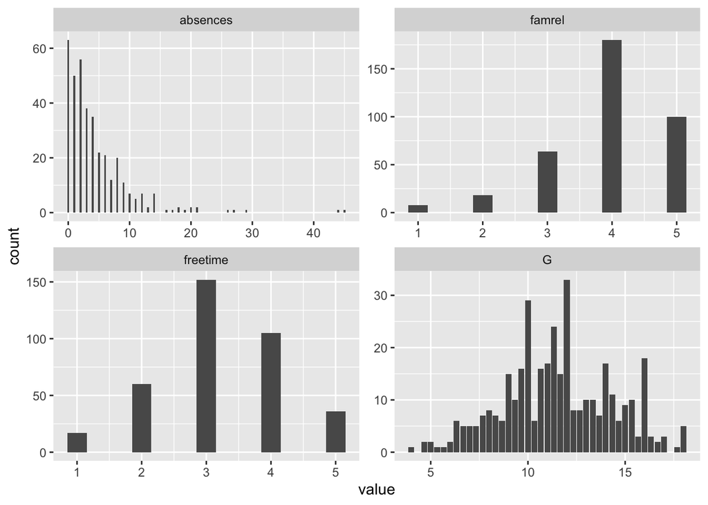

```r
# check the distribution with bar plots
bar <- select(alc, "G", "freetime", "absences", "famrel")
gather(bar) %>% ggplot(aes(value)) + facet_wrap("key", scales = "free") + geom_bar()
```

The plots show the following:

- the number of absences has only one peak that is in 0-10, so mainly students have 0 jr only several absences
- for main part of students quality of family relations can be estimated as good
- for main part of students amount of free time can be estimated as average and high
- the most frequent final grades are in 10-16 gap

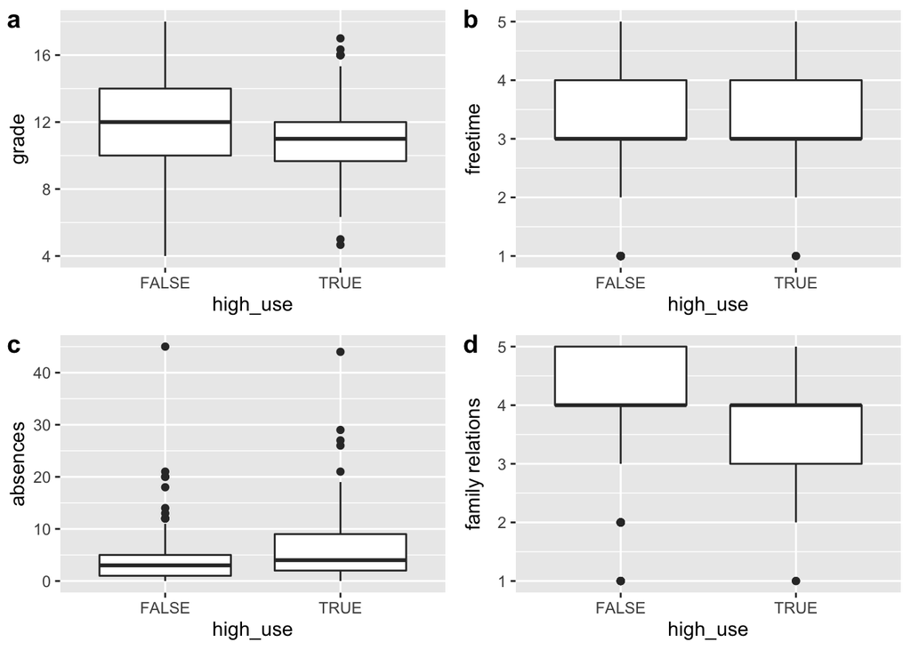

```r
# check the distribution with box plots
# for high_use variable TRUE is for students for which 'alc_use' is greater than 2, otherwise FALSE
# G is a mean grade
d1 <- ggplot(alc, aes(x = high_use, y = G)) + geom_boxplot() + ylab("grade")
d2 <- ggplot(alc, aes(x = high_use, y = freetime)) + geom_boxplot()
d3 <- ggplot(alc, aes(x = high_use, y = absences)) + geom_boxplot()
d4 <- ggplot(alc, aes(x = high_use, y = famrel)) + geom_boxplot() + ylab("family relations")

d <- plot_grid(d1, d2, d3, d4, labels = c('a', 'b', 'c', 'd'),align="hv")
d
```

The box plots show the following:

1. for mean grade and alcohol assumption(AA) plot the median for students with AA less than 2, is higher and there is an evidence that there are more students from this group that have higher mean grade, so we can confirm our hypothesis: alcohol assumption decreases grades
2. free time and alcohol assumption(AA) plot presents equal results, so we can’t confirm our hypothesis
3. for absences and alcohol assumption(AA) plot the median is mainly the same for both students’ groups and the number of absences is low. However, for those with AA grater than 2 we have more observations, so we can confirm our hypothesis: alcohol assumption is increased by the number of school absences
4. for family relations and alcohol assumption(AA) plot the median is the same and relations in families students mainly estimate as good but the group with AA more than 2, students estimate the relations worse, so we can assume that our hypothesis can be confirmed: the worse relationships in the family, the higher alcohol assumption is

## Logistic regression

Let’s create a logistic regression model with the binary high/low alcohol consumption variable as the target and these explanatory variables: “freetime”, “G” (grades), “absences”, “famrel”

```r
model <- glm(high_use ~ freetime + G + absences + famrel, data = alc, family = "binomial")
summary(model)
```

```
##
## Call:
## glm(formula = high_use ~ freetime + G + absences + famrel, family = "binomial",
##     data = alc)
##
## Deviance Residuals:
##     Min       1Q   Median       3Q      Max
## -1.8494  -0.8183  -0.6309   1.1567   2.0665
##
## Coefficients:
##             Estimate Std. Error z value Pr(>|z|)
## (Intercept) -0.29109    0.80769  -0.360 0.718552
## freetime     0.44845    0.12807   3.502 0.000463 ***
## G           -0.09783    0.04359  -2.244 0.024810 *
## absences     0.08204    0.02249   3.648 0.000264 ***
## famrel      -0.34003    0.13016  -2.612 0.008989 **
## ---
## Signif. codes:  0 '***' 0.001 '**' 0.01 '*' 0.05 '.' 0.1 ' ' 1
##
## (Dispersion parameter for binomial family taken to be 1)
##
##     Null deviance: 452.04  on 369  degrees of freedom
## Residual deviance: 411.59  on 365  degrees of freedom
## AIC: 421.59
##
## Number of Fisher Scoring iterations: 4
```

```r
coef(model)
```

```
## (Intercept)    freetime           G    absences      famrel
## -0.29108828  0.44845029 -0.09783016  0.08203815 -0.34002935
```

```r
odds <- coef(model) %>% exp
confi <- confint(model) %>% exp
cbind(odds, confi)
```

```
##                  odds     2.5 %    97.5 %
## (Intercept) 0.7474497 0.1514430 3.6313994
## freetime    1.5658836 1.2235216 2.0238304
## G           0.9068029 0.8315906 0.9870153
## absences    1.0854972 1.0407617 1.1372571
## famrel      0.7117494 0.5501574 0.9182071
```

The model shows the following:

From p-values we can conclude that our variable are statistically significant.

## Predictive power of the model

```r
# remove grades (G)
newmodel <- glm(high_use ~ freetime + G + absences + famrel, data = alc, family = "binomial")
summary(newmodel)
```

```
##
## Call:
## glm(formula = high_use ~ freetime + G + absences + famrel, family = "binomial",
##     data = alc)
##
## Deviance Residuals:
##     Min       1Q   Median       3Q      Max
## -1.8494  -0.8183  -0.6309   1.1567   2.0665
##
## Coefficients:
##             Estimate Std. Error z value Pr(>|z|)
## (Intercept) -0.29109    0.80769  -0.360 0.718552
## freetime     0.44845    0.12807   3.502 0.000463 ***
## G           -0.09783    0.04359  -2.244 0.024810 *
## absences     0.08204    0.02249   3.648 0.000264 ***
## famrel      -0.34003    0.13016  -2.612 0.008989 **
## ---
## Signif. codes:  0 '***' 0.001 '**' 0.01 '*' 0.05 '.' 0.1 ' ' 1
##
## (Dispersion parameter for binomial family taken to be 1)
##
##     Null deviance: 452.04  on 369  degrees of freedom
## Residual deviance: 411.59  on 365  degrees of freedom
## AIC: 421.59
##
## Number of Fisher Scoring iterations: 4
```

Cross tabulation of predictions versus the actual values:

```r
probabilities <- predict(newmodel, type = "response")
alc <- mutate(alc, probability = probabilities)
alc <- mutate(alc, prediction = probability > 0.5)
select(alc, freetime, G, absences, famrel, high_use, probability, prediction) %>% tail(10)
```

```
##     freetime         G absences famrel high_use probability prediction
## 361        4 12.666667        3      4    FALSE   0.2993338      FALSE
## 362        3  4.000000        0      4    FALSE   0.3324388      FALSE
## 363        4  4.666667        7      5     TRUE   0.4800836      FALSE
## 364        3 12.333333        1      5    FALSE   0.1454904      FALSE
## 365        4  7.000000        6      4    FALSE   0.4875059      FALSE
## 366        4  7.000000        2      5    FALSE   0.3277964      FALSE
## 367        3 11.666667        2      4    FALSE   0.2170178      FALSE
## 368        1  6.666667        3      1    FALSE   0.3569208      FALSE
## 369        4 12.666667        4      2     TRUE   0.4779205      FALSE
## 370        4 10.666667        2      4     TRUE   0.3236934      FALSE
```

```r
table(high_use = alc$high_use, prediction = alc$prediction)
```

```
##         prediction
## high_use FALSE TRUE
##    FALSE   244   15
##    TRUE     90   21
```

As it can be seen from the table, the model correctly classified 244+21=265 observations and failed with 90+15= 105 observations, the training error is 105/(265+105) = 0.28.

```r
# define average prediction error
loss_func <- function(class, prob) {
  n_wrong <- abs(class - prob) > 0.5
  mean(n_wrong)
}
loss_func(class = alc$high_use, prob = alc$probability)
```

```
## [1] 0.2837838
```

We can see that the results are the same.

```r
# if try to guess
mean(alc$high_use)
```

```
## [1] 0.3
```

So, with simple guessing we can assume that 30% goes to mistake and the model gives 28%. It means that the model is a bit more precise results.